# Skilled Nursing Facility Strategic Benchmark Report

Client-specific static report from CMS SNF cost-report metrics

# Executive summary

SANDSTONE BOUNTIFUL | CCN 465156 | BOUNTIFUL, UT | DAVIS County

**Overall read: census/utilization appears weaker than similar peers; net patient revenue per resident day exceeds operating expense per resident day; patient service margin is positive; contract labor reliance may warrant review.**

**Facility:** SANDSTONE BOUNTIFUL  
**CCN:** 465156  
**Location:** BOUNTIFUL, UT; DAVIS County  
**Latest cost-report year:** 2023  
**Peer group:** Same state + same rural/urban + same bed-size band; n = 27.

This report summarizes cost-report-based strategic indicators for the selected skilled nursing facility. It is designed as a first-pass consulting report, not a substitute for audited financial review, facility interviews, staffing data, quality measures, or referral-market analysis.

- Latest occupancy is **45.7%**, compared with a peer median of **67.4%**; the three-year change is down 0.4% from 2020 to 2023.
- Medicare day share is **15.8%** and Medicaid day share is **53.7%**, giving an initial view of post-acute versus long-stay payer mix.
- Net patient revenue per resident day is **$415**, while operating expense per resident day is **$408**.
- Patient service margin is **1.7%**, compared with a peer median of **0.0%**.
- Contract labor ratio is **34.8%**, compared with a peer median of **8.1%**.

## How to read this report

- **Peer comparisons** use the selected facility’s latest-year peer group: same state, same rural/urban category, and same bed-size band.
- **Trend charts** compare the target facility with the latest-year peer group over time. The shaded band is the peer 25th to 75th percentile range; the dashed line is the peer median; the solid line is the target facility.
- **Cost-report metrics are screening indicators.** They are useful for identifying likely issues and follow-up questions, but they should be validated with staffing, quality, survey, referral, rate, and management information before making operational recommendations.

# Rule-based strategic flags

Risk · Utilization

Occupancy trails peers

Latest occupancy is more than five percentage points below the peer median.

Watch · Utilization

Average daily census is small versus peers

Average daily census is less than roughly 75% of the peer median, which can raise fixed cost per day.

Watch · Labor

Contract labor reliance is elevated

Contract labor ratio is above the peer 75th percentile or above 10%.

# Facility profile

| Field | Value |
| --- | --- |
| Facility | SANDSTONE BOUNTIFUL |
| CCN | 465156 |
| City | BOUNTIFUL |
| County | DAVIS |
| ZIP | 84010 |
| Rural/urban | Urban |
| Ownership/control code | 4 |
| Beds | 122.0 |
| Bed-size band | 100-149 |
| SNF/NF mix | SNF-dominant |
| Latest cost-report year | 2023 |
| Peer group | Same state + same rural/urban + same bed-size band; n = 27 |
| Data quality flags | None listed |

# Latest-year benchmark table

| Metric | Target | Peer median | Peer p25 | Peer p75 | Difference | Percentile |
| --- | --- | --- | --- | --- | --- | --- |
| Utilization |  |  |  |  |  |  |
| Occupancy rate | 45.7% | 67.4% | 60.8% | 82.8% | -21.7% | 11% |
| Payer mix |  |  |  |  |  |  |
| Medicare day share | 15.8% | 6.7% | 4.2% | 9.4% | 9.1% | 89% |
| Medicaid day share | 53.7% | 65.4% | 54.3% | 71.4% | -11.7% | 22% |
| Revenue |  |  |  |  |  |  |
| Net patient revenue per resident day | $415 | $396 | $370 | $431 | $19 | 63% |
| Cost |  |  |  |  |  |  |
| Operating expense per resident day | $408 | $391 | $363 | $420 | $17 | 63% |
| Margin |  |  |  |  |  |  |
| Patient service margin | 1.7% | 0.0% | -7.8% | 6.8% | 1.8% | 63% |
| Total margin | 2.7% | 6.9% | -2.6% | 10.6% | -4.2% | 39% |
| Labor |  |  |  |  |  |  |
| Contract labor ratio | 34.8% | 8.1% | 3.5% | 18.3% | 26.7% | 100% |
| Liquidity |  |  |  |  |  |  |
| Days cash on hand | 38.9 | 14.6 | 0.8 | 44.3 | 24.2 | 70% |
| Current ratio | 1.0 | 1.8 | 1.1 | 3.9 | -0.8 | 22% |
| Solvency |  |  |  |  |  |  |
| Debt to assets | 100.7% | 65.0% | 34.0% | 98.8% | 35.8% | 93% |

# Trend analysis

Trend charts show the selected facility against the latest-year peer group where peer comparison is available. Payer mix and revenue-versus-expense charts are target operating views intended to show how the facility’s own business model has changed over time.

## Occupancy

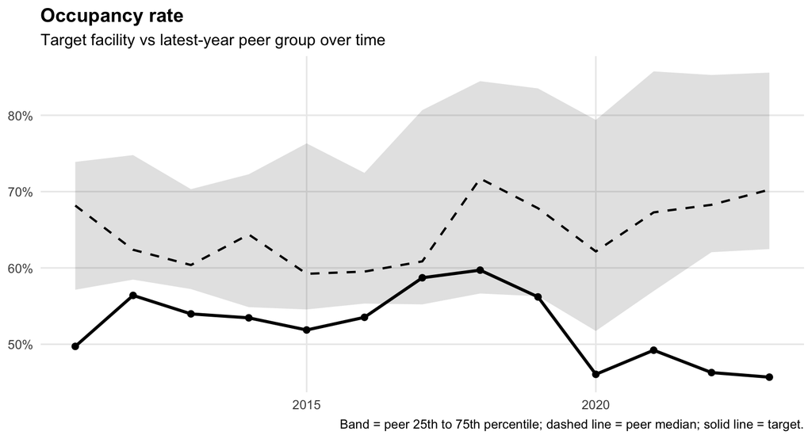

**Interpretation:** Occupancy is the clearest capacity-utilization signal in the cost report. A target line below the peer median suggests census pressure; a target line above peers suggests stronger utilization or a different care model.

## Payer mix

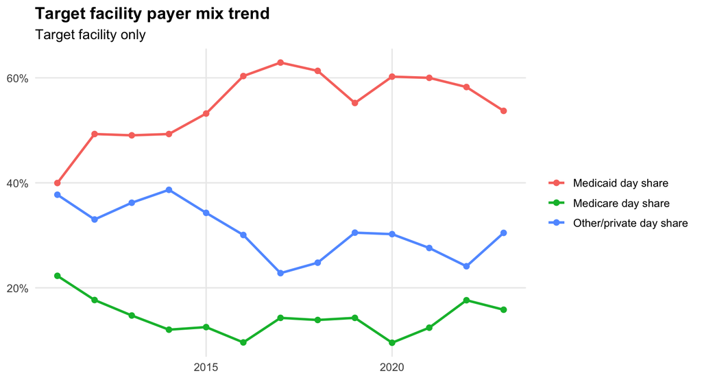

**Interpretation:** Medicare share is a rough proxy for skilled/post-acute orientation, while Medicaid share often reflects long-stay reimbursement exposure. Directional change can matter as much as the latest value.

## Revenue and operating expense per resident day

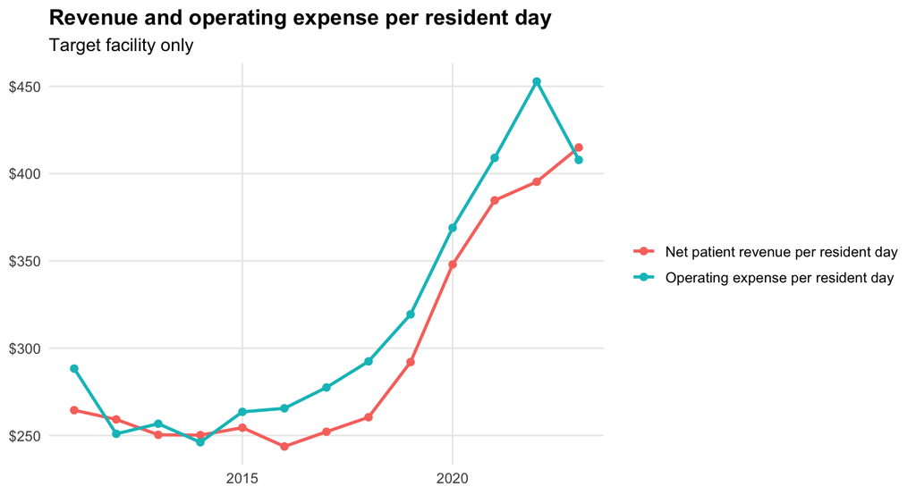

**Interpretation:** If operating expense per day is growing faster than revenue per day, the facility may be facing margin compression even if occupancy is stable.

## Patient service margin

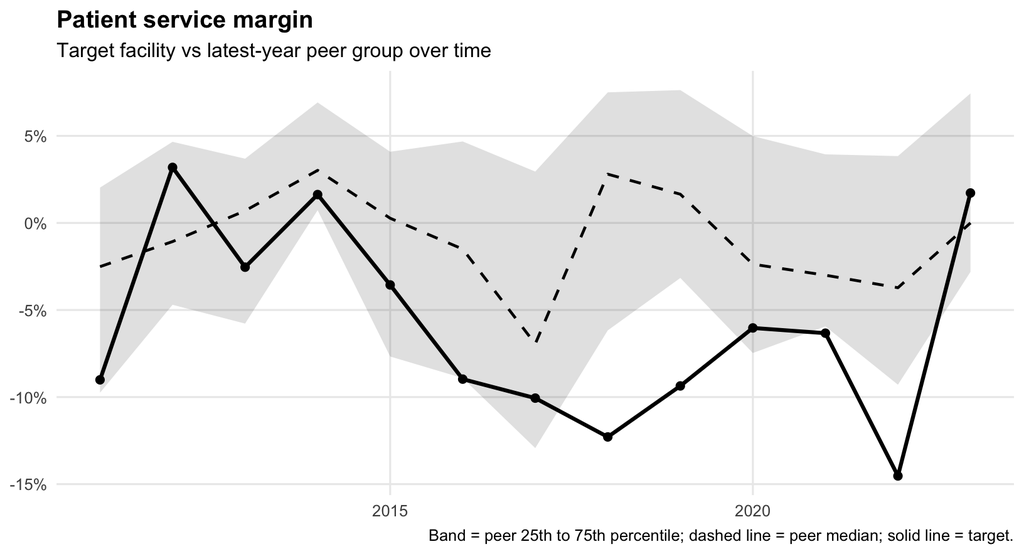

**Interpretation:** Patient service margin shows whether resident-care operations appear financially sustainable based on cost-report fields. A persistent negative margin requires deeper review of payer mix, labor cost, overhead, occupancy, and accounting treatment.

## Contract labor ratio

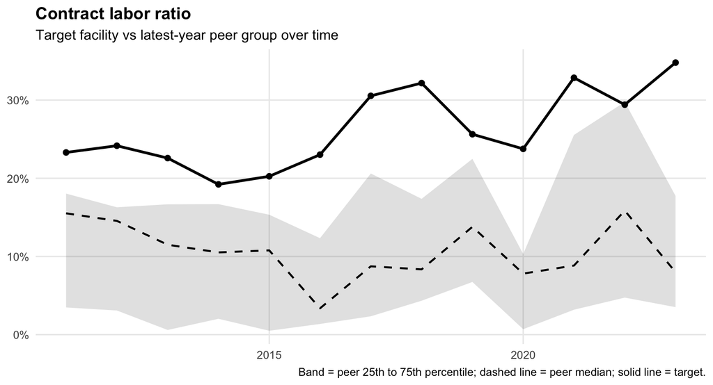

**Interpretation:** Contract labor ratio is a screening indicator for agency or contracted labor reliance. A high or rising value may suggest staffing instability, wage pressure, or temporary surge staffing, but it should be validated with PBJ staffing data.

# Consulting implications and next questions

The cost report points to financial, utilization, payer-mix, labor, and liquidity patterns. Before making operational recommendations, the next consulting step should validate these findings with additional sources:

- PBJ staffing data for RN/LPN/CNA staffing and agency reliance.
- Care Compare quality, survey, and deficiency data.
- Local hospital discharge and referral-market context.
- Medicaid rate and managed care context.
- Leadership interview or facility operating review.

**Source:** Centers for Medicare & Medicaid Services (CMS), Healthcare Cost Report Information System (HCRIS), Skilled Nursing Facility Cost Report public-use data (CMS-2540-10). This report uses cleaned Utah facility cost-report years 2011–2023 from CMS source files spanning 2010–2024. Cost-report metrics are unaudited screening indicators and should be validated with staffing, quality, survey, referral-market, rate, and management information before making operational recommendations.